# Food at College

```r
# From your file menu (at the top of R-Studio) select:
# "Session -> Set working directory -> To source file location"
# Then play this chunk to get the data into R.
library(mosaic)
library(car)
library(DT)
library(pander)
library(readr)
food <- read_csv("../../Data/food.csv") #food.csv is in the Data folder...
```

### Background

A survey was conducted in the Mercyhurst University to gather data about food choices and preferences of college students. It includes datapoints on values such as their GPA, Weight, Cooking frequency, etc. [You can view the dataset here.](https://www.kaggle.com/datasets/borapajo/food-choices)

This analysis seeks to answer the following questions:

**1. What does the body weight distribution of Mercyhurst University students look like?**

**2. Does a student’s cooking affect their reported weight in lbs?**

Cooking Frequency is defined in the survey as follows:

**1. Cooks Everyday**

**2. A couple times a week**

**3. Whenever I can, but not very often**

**4. I only help a little during holidays**

**5. Never, I don’t really know my way around a kitchen**

### Cleaning the Data

```r
df <- food %>%
  group_by(cook) %>%
  select(cook, weight)

df <- df %>%
  mutate(
  weight = case_when(
    weight == "144 lbs" ~ "144",
    TRUE ~ weight
  )
)

df$weight <- as.numeric(df$weight)

df <- df %>%
  filter(!(is.na(cook))) %>%
  filter(!(is.na(weight)))

errant <- food %>%
  group_by(cook) %>%
  select(cook,weight)

errant_values <- food %>%
  mutate(weight_num = suppressWarnings(as.numeric(weight))) %>%
  filter(is.na(weight_num) & !is.na(weight)) %>%
  select(cook, weight)
```

There are a couple of errant values that were found in the data set as shown below.”I’m not answering”, and “Not sure” were both dropped, while “144 lbs” was converted to 144 to conform with the other numeric values in the dataset.

```r
datatable(errant_values)
```

|  | cook | weight |
| --- | --- | --- |
| 1 | 1 | I'm not answering this. |
| 2 | 2 | Not sure, 240 |
| 3 | 4 | 144 lbs |

Here is a datatable of the cleaned dataset:

```r
datatable(df)
```

|  | cook | weight |
| --- | --- | --- |
| 1 | 2 | 187 |
| 2 | 3 | 155 |
| 3 | 1 | 190 |
| 4 | 3 | 190 |
| 5 | 2 | 180 |
| 6 | 3 | 137 |
| 7 | 3 | 180 |
| 8 | 3 | 125 |
| 9 | 1 | 116 |
| 10 | 3 | 110 |

[output cut: 108 more lines]

### Hypothesis

$$H_0: \text{All samples represent a
sample of data from the same distribution.}$$
$$H_a: \text{At least one distribution is
stochastically different than the others.}$$
$$\alpha = 0.05$$

### Analysis

The side by side box plots of the sample display that those who cook whenever they can and those who cook a couple times a week have the lightest median weight @ 150 lbs and 152.5 lbs respectively. On the other hand those who appear to have the highest median weight are those who never cook @ 175 lbw. Despite this, the box-plots appear quite similar and have no notable variation.

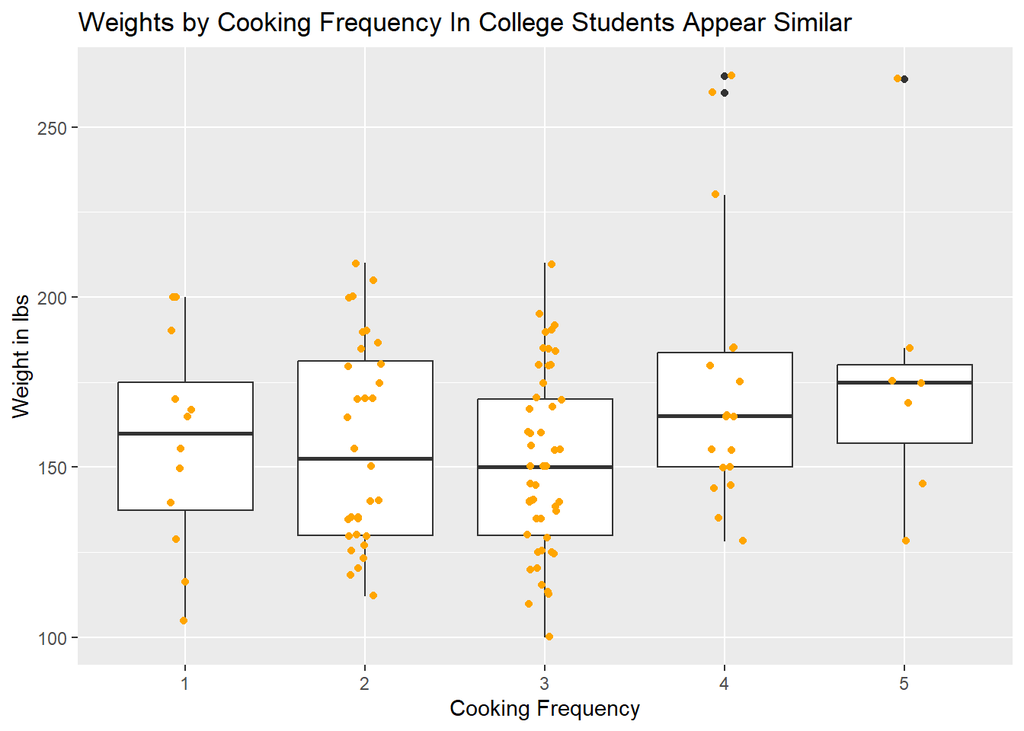

```r
df %>%
  ggplot(aes(x = as.factor(cook), y = weight, fill = ))+
  geom_boxplot()+
  geom_jitter(width = 0.1, color = "orange")+
  labs(x = "Cooking Frequency", y = "Weight in lbs", title = "Weights by Cooking Frequency In College Students Appear Similar")
```

```r
favstats(weight ~ cook, data = df) %>%
  pander(caption = "Summary Statistics for Cooking Frequency and Weight")
```

Summary Statistics for Cooking Frequency and Weight

| cook | min | Q1 | median | Q3 | max | mean | sd | n | missing |
| --- | --- | --- | --- | --- | --- | --- | --- | --- | --- |
| 1 | 105 | 137.2 | 160 | 175 | 200 | 157.2 | 31.09 | 12 | 0 |
| 2 | 112 | 130 | 152.5 | 181.2 | 210 | 156.8 | 29.72 | 32 | 0 |
| 3 | 100 | 130 | 150 | 170 | 210 | 151.1 | 26.53 | 49 | 0 |
| 4 | 128 | 150 | 165 | 183.8 | 265 | 174.3 | 39.55 | 18 | 0 |
| 5 | 128 | 157 | 175 | 180 | 264 | 177.3 | 43.07 | 7 | 0 |

```r
kruskal.test(weight ~ cook, data = df) %>%
  pander()
```

Kruskal-Wallis rank sum test: `weight` by `cook`

| Test statistic | df | P value |
| --- | --- | --- |
| 5.539 | 4 | 0.2364 |

Because the P-value is P = 0.2364 > $\alpha = 0.05$, there is insufficient evidence to reject the null hypothesis that each of these represents a sample from the same distribution. We can continue to assume that the weight distributions are the same across all cooking frequency ranks.

### Conclusion

Because the P-value was found to be at P = 0.2364 > $\alpha = 0.05$ by running the Kruskal-Wallis rank sum test, we can assume that all samples come from the same distribution. From this we can infer that, in general the frequency that college students cook don’t seem to affect their weight.

To answer our first question about the shape of the distribution of student weights in this university, we can use a histogram and summary statistics table. It appears that the sample distribution is mostly right skewed with most of the student’s weights range from 100 - 200 lbs, with only a few values exceeding that and pulling the distribution to the right.

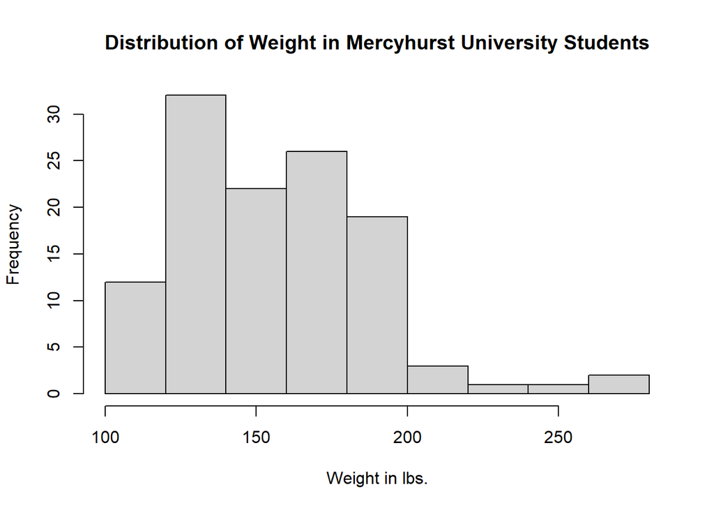

```r
hist(df$weight,xlab = "Weight in lbs.", ylab = "Frequency", main = "Distribution of Weight in Mercyhurst University Students")
```

```r
favstats(df$weight) %>%
  pander(caption = "Summary Statistics of the Weight of Mercyhurst University Students")
```

Summary Statistics of the Weight of Mercyhurst University Students

| min | Q1 | median | Q3 | max | mean | sd | n | missing |
| --- | --- | --- | --- | --- | --- | --- | --- | --- |
| 100 | 135 | 155 | 180 | 265 | 158.3 | 31.93 | 118 | 0 |